# Premier League Dataset Explanatory

## by Omar Farouk

## Investigation Overview

> The football matches are unpredictable, could we have any chance to know what can affect the results of the matches?  
> We will investigate about some match stats as:
> - Does playing at home stadium gives you more advantage on the other team?
> - Does the number of shots affect the results?
> - Does the number of attenance of fans in the match can make differnces in the result of the match? We will see some visualizations which may answer these questions.

## Dataset Overview

> Provide a brief overview of the dataset to be presented here. The dataset is about Premier League from season 2011/12 to season 2019/20,it contains 3327 matches. The dataset is about stats of the matches like passes, shots, possession, attendance.

## Wins rate to Home teams and Away teams.

> The win rate for the home team is 45.5% and the win rate for the away team is 30.3%, the rest is about tie between both teams (24.2%). it is abvoius that the Home team has higher probability than the Away team to win the match at home stadium.

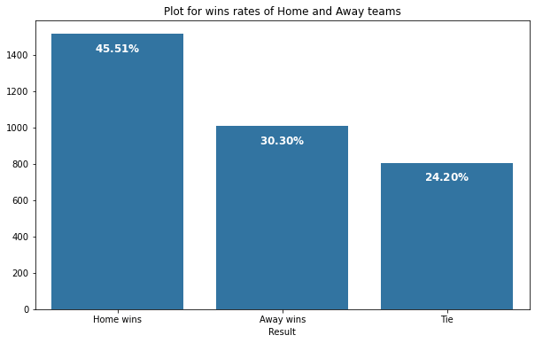

```python
plt.figure(figsize=(10,6))
base_color = sb.color_palette()[0]

x_ticks_labels = ['Home wins', 'Away wins', 'Tie']
sb.countplot(data=df_base, x='result', order=res_order, color=base_color);
plt.xticks([0,1,2], x_ticks_labels);
plt.xlabel('Result')
plt.ylabel('')
plt.title('Plot for wins rates of Home and Away teams')

for i in range(res_counts.shape[0]):
    count = res_counts[i]
    p_str = r"$\bf{" + '{:.2f}'.format(count/n_res*100) + r"\%}$"
    plt.text(i,res_counts[i]-50, p_str, ha = 'center', va='top', color='white', fontsize=12)
```

## Distribution of scored goals

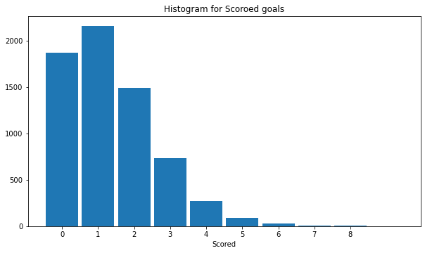

```python
plt.figure(figsize=(10,5.5))
bins = np.arange(-0.5,9.5+1 , 1)
plt.hist(data=df_mod, x='scored', bins=bins, rwidth = 0.9);
plt.title('Histogram for Scoroed goals')
plt.xticks(np.arange(0, 9, 1));
plt.xlabel('Scored');
```

## Scatter plot for Number of scored goals vs number of shots

> It is resonable for figure to desribe the postive relation between them, when the team shots a large number of balls, he is having a great chance to score more goals. but you can shot large number of balls and dont score any of them.

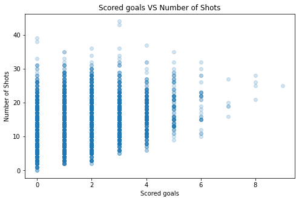

```python
plt.figure(figsize=(8,5))
sb.regplot(data=df_mod, x='scored', y='shots', scatter_kws={"alpha":1/5},fit_reg=False);
plt.xlabel('Scored goals');
plt.ylabel('Number of Shots');
plt.title('Scored goals VS Number of Shots');
```

## Box plot between Results (Win , Tie, Lose) and Ball Possession

> Here, The teams with high possession on ball has higher chance to win the match, as we see the differnce between win and lose is small, so it is not a rule. sometimes the losing team has ball possesion higher than the winning team.

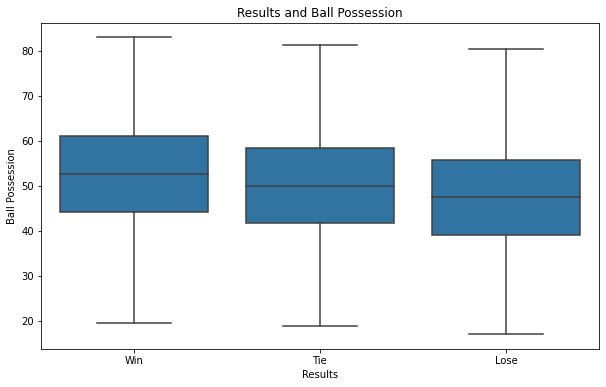

```python
# boxplot between Result and possession
plt.figure(figsize=(10,6))
sb.boxplot(data=df_mod, y='posse', x='result', color=base_color);
plt.title('Results and Ball Possession')
plt.xlabel('Results')
plt.xticks([0,1,2], ['Win', 'Tie', 'Lose'])
plt.ylabel('Ball Possession');
```

## Number of passes vs Number of shots by the Result

> The figure descibes that the the team that has high number of shots and passes has higher chance to win the game.

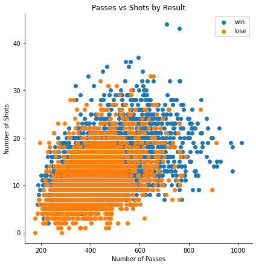

```python
g = sb.FacetGrid(data=df_mod, hue='result', height=6,hue_order=['win', 'lose']);
g.map(plt.scatter, 'passes', 'shots');
plt.legend();
plt.title('Passes vs Shots by Result');
plt.xlabel('Number of Passes');
plt.ylabel('Number of Shots');
```

## Shots by Result and Team Hospitality

> it is obviuos that the winner of the team has average shots more than the losing team, whatever the winning team is playing at home or away.

[figure not shown]

```python
plt.figure(figsize=(8,6))
sb.pointplot(data = df_mod, x = 'team_hospitality', y = 'shots',order=order_dic['team_hospitality'],ci='sd',
           hue = 'result', hue_order=['win', 'lose'], linestyles = '', dodge=0.1)
plt.ylim((0,24));
plt.xlabel('Team Hospitality')
plt.ylabel('Mean of Shots')
plt.title('Attendance by Result');
```

# The Results(who wins) distrubution vs Attenance

> Not just playing at home stadium guarantees higher chance to win the game, also if they have large number of fans attended the match, their chance will increase to win the game.

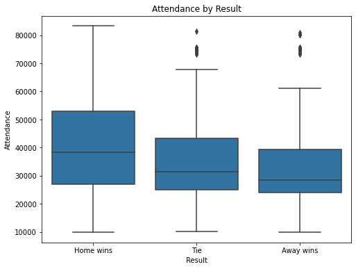

```python
plt.figure(figsize=(8,6))
res_order = ['home', 'tie', 'away']
x_ticks_labels = ['Home wins', 'Tie', 'Away wins']
sb.boxplot(data=df_base, x='result', y='attendance',color=base_color, order=res_order)
plt.xticks([0, 1, 2], x_ticks_labels);
plt.xlabel('Result')
plt.ylabel('Attendance')
plt.title('Attendance by Result');
```